# IP Course 2024

2024-05-14

#### e-mail: **marco.lafortezza@env.ethz.ch**.

#### All you need: **[GitHub](https://github.com/MarcoLF/IP_course_2024)**.

## Getting ready

Load all dependencies that are required for this exercise. The following code will automatically install all the dependency that are not already present in your computer.

```r
if (!require("pacman"))
  install.packages("pacman")
```

```r
pacman::p_load(car, reshape2, plyr, ggplot2, Hmisc, multcomp, colorDF)
```

Let’s start by uploading our data set. Make sure to specify your directory properly. Here, if your dog ate your dataset or you had major issues in plating you can use directly access a data set from *GitHub*. However, remember that later you will need to test some of your own data…

```r
input = "https://raw.githubusercontent.com/MarcoLF/IP_course_2024/main/IP%20course.csv"
IP = as.data.frame(read.csv(input))
IP$Plate = as.factor(IP$Plate)
IP$Site = as.factor(IP$Site)
```

First of all let’s have a look at the data.

```r
head(IP) #it shows by default the first 6 rows of the data set
```

```
##   Student  Plate Site CFU Dil.number Dil.factor CFU.ml CFU.gram Log.CFU.gram
## 1       I     R2    A  15          3          4 150000   570342          5.8
## 2       I R2-Amp    A  90          2          3  90000   342205          5.5
## 3       I R2-Chl    A  12          2          3  12000    45627          4.7
## 4       I R2-Cip    A 100          2          3 100000   380228          5.6
## 5       I R2-Kan    A  70          1          2   7000    26616          4.4
## 6       I R2-Rif    A  18          2          3  18000    68441          4.8
##   Abr.prc
## 1      NA
## 2    60.0
## 3     8.0
## 4    66.6
## 5     4.6
## 6    12.0
```

```r
str(IP) #it shows the internal structure of the data set
```

```
## 'data.frame':    56 obs. of  10 variables:
##  $ Student     : chr  "I" "I" "I" "I" ...
##  $ Plate       : Factor w/ 7 levels "R2","R2-Amp",..: 1 2 3 4 5 6 7 1 2 3 ...
##  $ Site        : Factor w/ 2 levels "A","B": 1 1 1 1 1 1 1 2 2 2 ...
##  $ CFU         : int  15 90 12 100 70 18 60 200 60 70 ...
##  $ Dil.number  : int  3 2 2 2 1 2 2 1 1 1 ...
##  $ Dil.factor  : num  4 3 3 3 2 3 3 2 2 2 ...
##  $ CFU.ml      : int  150000 90000 12000 100000 7000 18000 60000 20000 6000 7000 ...
##  $ CFU.gram    : int  570342 342205 45627 380228 26616 68441 228137 70175 21053 24561 ...
##  $ Log.CFU.gram: num  5.8 5.5 4.7 5.6 4.4 4.8 5.4 4.8 4.3 4.4 ...
##  $ Abr.prc     : num  NA 60 8 66.6 4.6 12 40 NA 30 35 ...
```

This exercise focuses on the realization of Fig 7 (ref to Labnote II_2024.docx). With this specific figure we want to show all the differences found about the AB resistance across sites. It is usually a good practice to first sketch on paper the final graph we want to obtain. In this specific case, we aim to represent the CFU that we measured as a function of both plate type (w/o AB, and AB type) and the sampling site (A or B). We are essentially referring to a simple model…

## the model

…that is

```r
model = aov(Log.CFU.gram ~ Plate + Site, data = IP) #note that we are already using the function for anova
```

However, we are also interested on whether the interaction between the two independent variables Plate and Site could explain possible differences. In other words we need to expand our model as

```r
model = aov(Log.CFU.gram ~ Plate + Site + Plate:Site, data = IP)
```

*Note* - **In R, the above syntax is identical to Log.CFU.gram ~ Plate*Site**

*Note* - **the model’s output contains a list of different arguments. To visualize them, just type: ls(model)**

Here, we use a *two-way ANOVA* to answer our question. Thus, it could be relevant to first check whether variances are homogeneous and data normally distributed. We can first compute *Residulas vs Fitted* values calculated from the model.

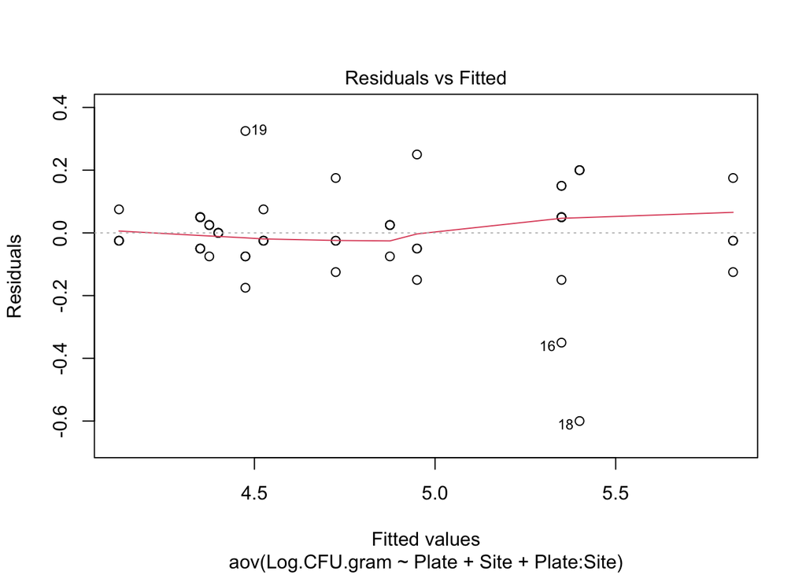

```r
plot(model, 1)
```

among all the data, the above graph shows that there are three data points (16, 18, 19; numbers refer to the raw entry in the data frame) that are actually considered to be outliers. In some instance, it is fine to remove those data as long as it is acknowledge to the reader. Also remember that outliers could be biologically informative. However, let’s first test formally for the homogeneity of the variances using the Levene’s test.

```r
leveneTest(Log.CFU.gram ~ Plate*Site, data = IP)
```

```
## Levene's Test for Homogeneity of Variance (center = median)
##       Df F value Pr(>F)
## group 13  0.6073 0.8341
##       42
```

The **Levene’s test** result in a **p-value = 0.83** which accepts the null-hypothesis. Thus, variances could be considered homogeneous.

*Note* - **In the previous command line I specify the model for clarity. Yet, we could have directly refer to the model using: levenTest(model)**

Let’s now check for normality. We do so by looking at the model’s residual distribution. First, we generate a graph that can already gives us a first picture on whether our data are normally distributed.

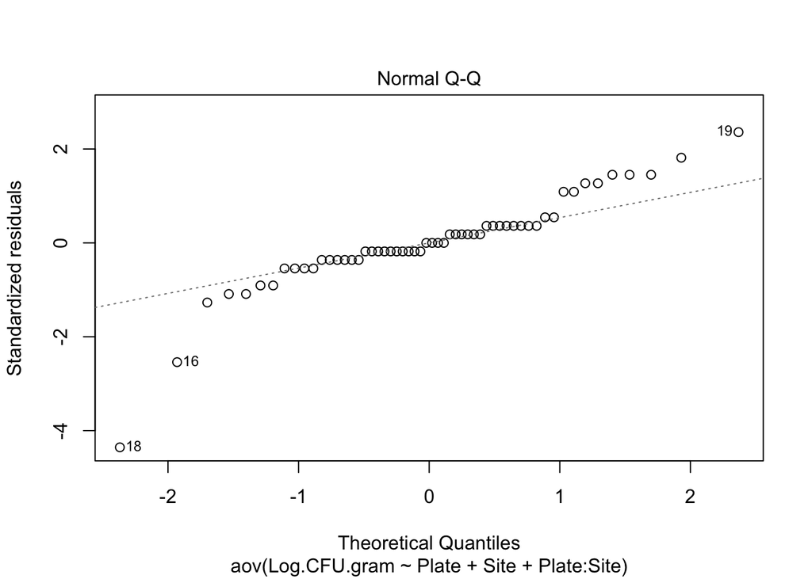

```r
plot(model, 2)
```

Already from the *Q-Q plot* we can see that the data are not very normally distributed. We can test this more formally by firstly extracting the actual residulas from our model and then using the Shapiro test for normality.

```r
resid = residuals(object = model)
shapiro.test(x = resid)
```

```
##
##  Shapiro-Wilk normality test
##
## data:  resid
## W = 0.87324, p-value = 2.844e-05
```

**Shapiro test** confirmed our expectation and rejected the null-hypothesis for normality. This is most likely associated with the low sampling number. However, ANOVA is not strongly affected by deviation from normality **(Harwell et al 1992, Lix et al. 1996)**, while it is crucial the variance homogeneity. An alternative can be rank transform the measured dependent variable (Log.CFU.gram), see later. For additional information on type of ranking-based transformation, check *Conover and Iman (1981)*.

## ggplot

Now it could be useful to generate the graph we are interested in. We do so by using the ggplot package. You can find **[online](https://ggplot2.tidyverse.org/)** a large number of tutorials explaining how this package works (for beginners and advanced users). Here, I try to guide you through the vary basic concepts of *ggplot* that are relevant to our aim. If you already know how to use it, you can skip this specific part. To use **ggplot** you first need to define the parameters you want to graph. Thus, you need to specify the source of your data **data** (e.g., where ggplot needs to get the data from), and then define what in ggplot are called *aesthetics*, a fancy way to say x and y axis (and more). In our case, the data corresponds to the data frame named **IP** and the aesthetics are **Log.CFU.gram** and **Plate**.

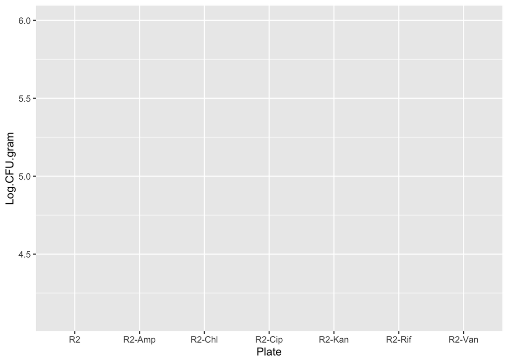

```r
ggplot(data = IP, aes(Plate, Log.CFU.gram)) #this is the base from where one starts to build the actual graph
```

Before plotting our data onto this gray area, there is an issue that maybe you have already noticed. At the beginning we mentioned *two* independent variables, but here, with this graph, we only have one which is **Plate**. How can we introduce the second variable that is the sampling **Site**? An easy way to do it is by coloring our data accordingly. We can expand the *aesthetics* with **col**.

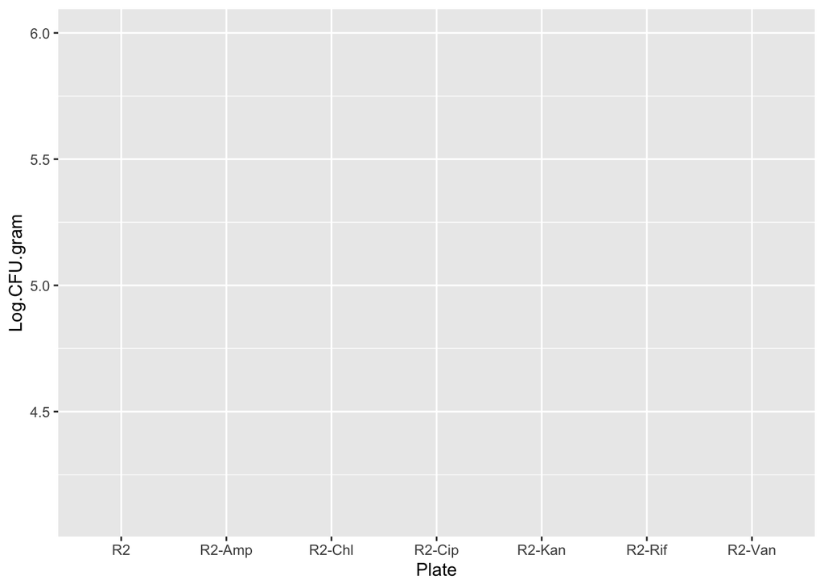

```r
ggplot(data = IP, aes(Plate, Log.CFU.gram, col = Site)) #this is the base from where one starts to build the actual graph
```

Amazing, still gray. Well, now we have all the bases and we can start to build our graph for real finally. To do so, we need to concatenate the first function *ggplot()* to others using the *+*. Specifically, now we will add our data as points and we also get rid of the gray background.

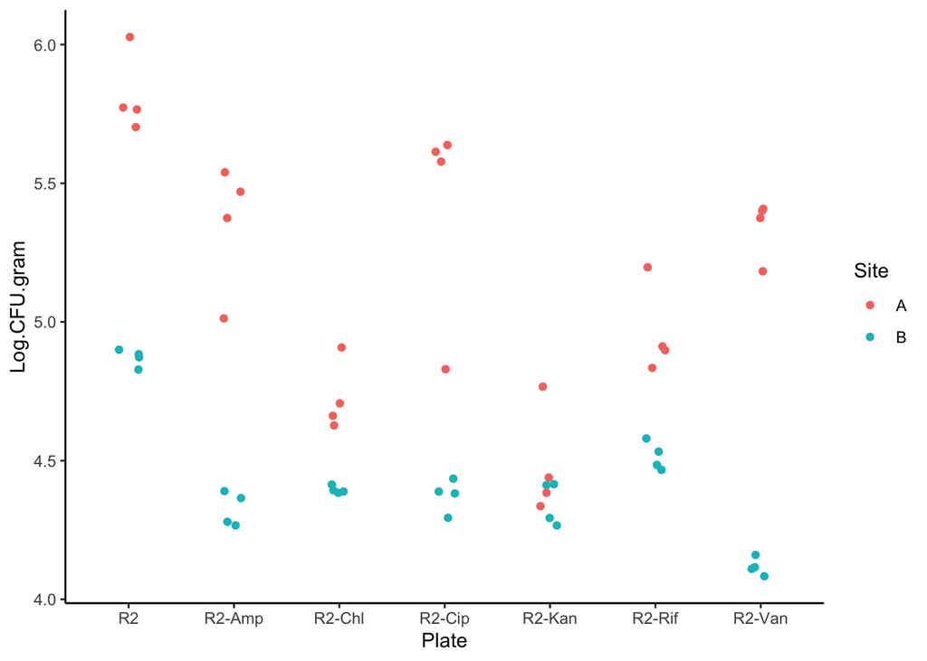

```r
ggplot(IP, aes(Plate, Log.CFU.gram, col = Site))+
  geom_jitter(width = 0.1)+ #this function spreads points along the x axis to avoid potential overlaps
  theme_classic() #just less gray and lines. see theme() in ggplot for more
```

We finally have our first data graph. It is important to look at this plot and see that there are already from here interesting observation that can be made. Some of them are explorative, other more inferential.

let’s continue with

## the actual test

In the previous graph we have plotted all the data point we have collected. However, we most likely want to report average values and the inferential errors that are associated to them. With ggplot there is a very smart way to do so. We can use the fucntion *stat_summary* that, as the name suggests, can be use to summarise the actual statistics of the plotted data.

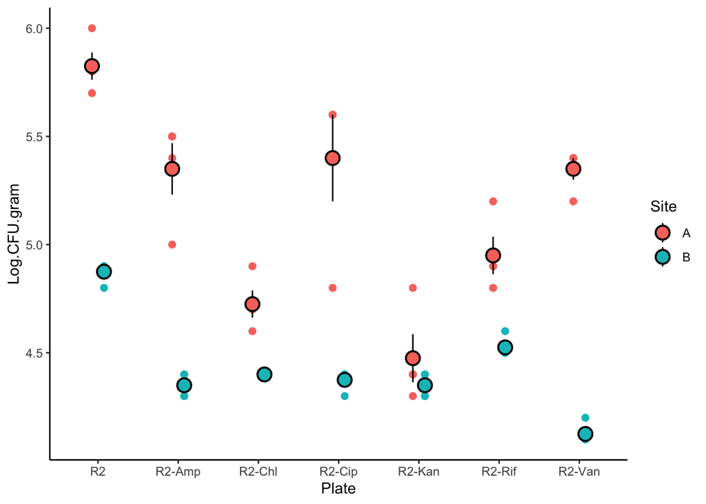

```r
ggplot(IP, aes(Plate, Log.CFU.gram, col = Site))+
  geom_point(position = position_dodge(width = 0.3), size = 2)+
  stat_summary(aes(fill = Site), fun.data = mean_se, geom = "pointrange",
               position = position_dodge(width = 0.3), col = "black", pch= 21, size = 1)+
  theme_classic()
```

Here, we are plotting the averages of 4 data points (4 independent measurements/students). The associated errors are SEM.

Now let’s work on the previous run *model* to better understand what we are observing on the above graph. Two-way ANOVA are usually performed on Type-III Sum Square (SS). SS tell us how much of the residual variability on our Y variable (Log.CFU.gram) is due to the factor e.g. *Plate* (but also *Site*) after having considered the factor *Site* (*Plate*) and the interaction *Site and Plate*. We can do so, by simply add the SS manually in the aov() function.

```r
model = aov(Log.CFU.gram ~ Plate + Site + Plate:Site, data = IP,
                contrasts = list(
    Plate = 'contr.sum',
    Site = 'contr.sum'))
Anova(model, type = 'III')
```

```
## Anova Table (Type III tests)
##
## Response: Log.CFU.gram
##              Sum Sq Df   F value    Pr(>F)
## (Intercept) 1285.44  1 50812.863 < 2.2e-16 ***
## Plate          4.21  6    27.748 4.029e-13 ***
## Site           7.36  1   290.887 < 2.2e-16 ***
## Plate:Site     2.15  6    14.181 9.467e-09 ***
## Residuals      1.06 42
## ---
## Signif. codes:  0 '***' 0.001 '**' 0.01 '*' 0.05 '.' 0.1 ' ' 1
```

We can now ask which of the different plates are characterized by a significant difference between *Sites*. We can take single pairs and test them individually. With some basic R knowledge this is extremely easy and very helpful, also with more complex data set than ours. Now it is very important to remember that the data are not normally distributed. Thus, if we would run a *t-test* we will increase considerably the chance of *Type-I Error*. We can instead use the *Wilcoxon test* that handles non-parametric distributions (another ranking approach).

We can increase the details of our analysis and ask for significant differences across all pairwise comparisons too. To do so, we cab run a *Wilcoxon Test* and correct the obtained *p-values* because of multiple testing.

```r
p.w.t = pairwise.wilcox.test(IP$Log.CFU.gram, paste(IP$Plate, IP$Site), paired = FALSE, p.adjust.method ="BH")$p.value

m.pwt = colorDF(melt(p.w.t, na.rm = T))
col_type(m.pwt, "value") <- "pval"

knitr::kable(m.pwt)
```

|  | Var1 | Var2 | value |
| --- | --- | --- | --- |
| 1 | R2 B | R2 A | 0.0404232 |
| 2 | R2-Amp A | R2 A | 0.0404232 |
| 3 | R2-Amp B | R2 A | 0.0404232 |
| 4 | R2-Chl A | R2 A | 0.0404232 |
| 5 | R2-Chl B | R2 A | 0.0404232 |
| 6 | R2-Cip A | R2 A | 0.0404232 |
| 7 | R2-Cip B | R2 A | 0.0404232 |
| 8 | R2-Kan A | R2 A | 0.0404232 |
| 9 | R2-Kan B | R2 A | 0.0404232 |
| 10 | R2-Rif A | R2 A | 0.0404232 |
| 11 | R2-Rif B | R2 A | 0.0404232 |
| 12 | R2-Van A | R2 A | 0.0404232 |
| 13 | R2-Van B | R2 A | 0.0404232 |
| 15 | R2-Amp A | R2 B | 0.0404232 |
| 16 | R2-Amp B | R2 B | 0.0404232 |
| 17 | R2-Chl A | R2 B | 0.1515187 |
| 18 | R2-Chl B | R2 B | 0.0404232 |
| 19 | R2-Cip A | R2 B | 0.2620091 |
| 20 | R2-Cip B | R2 B | 0.0404232 |
| 21 | R2-Kan A | R2 B | 0.0481671 |
| 22 | R2-Kan B | R2 B | 0.0404232 |
| 23 | R2-Rif A | R2 B | 0.7554868 |
| 24 | R2-Rif B | R2 B | 0.0404232 |
| 25 | R2-Van A | R2 B | 0.0404232 |
| 26 | R2-Van B | R2 B | 0.0404232 |
| 29 | R2-Amp B | R2-Amp A | 0.0404232 |
| 30 | R2-Chl A | R2-Amp A | 0.0404232 |
| 31 | R2-Chl B | R2-Amp A | 0.0404232 |
| 32 | R2-Cip A | R2-Amp A | 0.3342094 |
| 33 | R2-Cip B | R2-Amp A | 0.0404232 |

[output cut: 61 more lines]